# Personal_Loan_Campaign

```python
!pip install numpy pandas matplotlib seaborn scikit-learn sklearn-pandas -q --user
```

```python
# Libraries to help with reading and manipulating data
import pandas as pd
import numpy as np

# libaries to help with data visualization
import matplotlib.pyplot as plt
import seaborn as sns

# Removes the limit for the number of displayed columns
pd.set_option("display.max_columns", None)
# Sets the limit for the number of displayed rows
pd.set_option("display.max_rows", 200)

# Library to split data
from sklearn.model_selection import train_test_split

# To build model for prediction
from sklearn.tree import DecisionTreeClassifier
from sklearn import tree

# To tune different models
from sklearn.model_selection import GridSearchCV

# To get diferent metric scores
from sklearn.metrics import (
    f1_score,
    accuracy_score,
    recall_score,
    precision_score,
    confusion_matrix,
    make_scorer,
)

import warnings
warnings.filterwarnings("ignore")
```

```python
from google.colab import drive
drive.mount('/content/drive')
file_path = '/content/drive/MyDrive/Personal Loan Campaign/Loan_Modelling.csv'
Loan = pd.read_csv(file_path)
```

```python
data = Loan.copy()
```

```python
#first 5 rows
data.head()
```

|  | ID | Age | Experience | Income | ZIPCode | Family | CCAvg | Education | Mortgage | Personal_Loan | Securities_Account | CD_Account | Online | CreditCard |
| --- | --- | --- | --- | --- | --- | --- | --- | --- | --- | --- | --- | --- | --- | --- |
| 0 | 1 | 25 | 1 | 49 | 91107 | 4 | 1.6 | 1 | 0 | 0 | 1 | 0 | 0 | 0 |
| 1 | 2 | 45 | 19 | 34 | 90089 | 3 | 1.5 | 1 | 0 | 0 | 1 | 0 | 0 | 0 |
| 2 | 3 | 39 | 15 | 11 | 94720 | 1 | 1.0 | 1 | 0 | 0 | 0 | 0 | 0 | 0 |
| 3 | 4 | 35 | 9 | 100 | 94112 | 1 | 2.7 | 2 | 0 | 0 | 0 | 0 | 0 | 0 |
| 4 | 5 | 35 | 8 | 45 | 91330 | 4 | 1.0 | 2 | 0 | 0 | 0 | 0 | 0 | 1 |

```python
#last 5 rows
data.tail()
```

|  | ID | Age | Experience | Income | ZIPCode | Family | CCAvg | Education | Mortgage | Personal_Loan | Securities_Account | CD_Account | Online | CreditCard |
| --- | --- | --- | --- | --- | --- | --- | --- | --- | --- | --- | --- | --- | --- | --- |
| 4995 | 4996 | 29 | 3 | 40 | 92697 | 1 | 1.9 | 3 | 0 | 0 | 0 | 0 | 1 | 0 |
| 4996 | 4997 | 30 | 4 | 15 | 92037 | 4 | 0.4 | 1 | 85 | 0 | 0 | 0 | 1 | 0 |
| 4997 | 4998 | 63 | 39 | 24 | 93023 | 2 | 0.3 | 3 | 0 | 0 | 0 | 0 | 0 | 0 |
| 4998 | 4999 | 65 | 40 | 49 | 90034 | 3 | 0.5 | 2 | 0 | 0 | 0 | 0 | 1 | 0 |
| 4999 | 5000 | 28 | 4 | 83 | 92612 | 3 | 0.8 | 1 | 0 | 0 | 0 | 0 | 1 | 1 |

```python
#Shape of the data
data.shape
```

```
(5000, 14)
```

```python
#data types of the column
data.dtypes
```

|  | 0 |
| --- | --- |
| ID | int64 |
| Age | int64 |
| Experience | int64 |
| Income | int64 |
| ZIPCode | int64 |
| Family | int64 |
| CCAvg | float64 |
| Education | int64 |
| Mortgage | int64 |
| Personal_Loan | int64 |
| Securities_Account | int64 |
| CD_Account | int64 |
| Online | int64 |
| CreditCard | int64 |

**dtype:** object

```python
# Checking the statistical summary
data.describe().T
```

|  | count | mean | std | min | 25% | 50% | 75% | max |
| --- | --- | --- | --- | --- | --- | --- | --- | --- |
| ID | 5000.0 | 2500.500000 | 1443.520003 | 1.0 | 1250.75 | 2500.5 | 3750.25 | 5000.0 |
| Age | 5000.0 | 45.338400 | 11.463166 | 23.0 | 35.00 | 45.0 | 55.00 | 67.0 |
| Experience | 5000.0 | 20.104600 | 11.467954 | -3.0 | 10.00 | 20.0 | 30.00 | 43.0 |
| Income | 5000.0 | 73.774200 | 46.033729 | 8.0 | 39.00 | 64.0 | 98.00 | 224.0 |
| ZIPCode | 5000.0 | 93169.257000 | 1759.455086 | 90005.0 | 91911.00 | 93437.0 | 94608.00 | 96651.0 |
| Family | 5000.0 | 2.396400 | 1.147663 | 1.0 | 1.00 | 2.0 | 3.00 | 4.0 |
| CCAvg | 5000.0 | 1.937938 | 1.747659 | 0.0 | 0.70 | 1.5 | 2.50 | 10.0 |
| Education | 5000.0 | 1.881000 | 0.839869 | 1.0 | 1.00 | 2.0 | 3.00 | 3.0 |
| Mortgage | 5000.0 | 56.498800 | 101.713802 | 0.0 | 0.00 | 0.0 | 101.00 | 635.0 |
| Personal_Loan | 5000.0 | 0.096000 | 0.294621 | 0.0 | 0.00 | 0.0 | 0.00 | 1.0 |
| Securities_Account | 5000.0 | 0.104400 | 0.305809 | 0.0 | 0.00 | 0.0 | 0.00 | 1.0 |
| CD_Account | 5000.0 | 0.060400 | 0.238250 | 0.0 | 0.00 | 0.0 | 0.00 | 1.0 |
| Online | 5000.0 | 0.596800 | 0.490589 | 0.0 | 0.00 | 1.0 | 1.00 | 1.0 |
| CreditCard | 5000.0 | 0.294000 | 0.455637 | 0.0 | 0.00 | 0.0 | 1.00 | 1.0 |

```python
#Dropping Columns
data = data.drop(['ID'], axis=1)
```

```python
# Check for missing values
missing_values = data.isnull().sum()
print(missing_values)
```

```
Age                   0
Experience            0
Income                0
ZIPCode               0
Family                0
CCAvg                 0
Education             0
Mortgage              0
Personal_Loan         0
Securities_Account    0
CD_Account            0
Online                0
CreditCard            0
dtype: int64
```

```python
# Check for duplicate rows
duplicates = data.duplicated().sum()
print(f"Number of duplicate rows: {duplicates}")
```

```
Number of duplicate rows: 0
```

```python
#Ensure that the values in categorical variables like Education, Securities_Account, CD_Account, Online, and CreditCard are consistent and within expected ranges.
# Unique values in categorical columns
print(data['Education'].unique())
print(data['Securities_Account'].unique())
print(data['CD_Account'].unique())
print(data['Online'].unique())
print(data['CreditCard'].unique())
```

```
[1 2 3]
[1 0]
[0 1]
[0 1]
[0 1]
```

Exploratory Data Analysis

Analyze how different features are distributed based on whether a customer accepted the personal loan (Personal_Loan). This can help identify key differentiators between those who did and did not accept the loan.

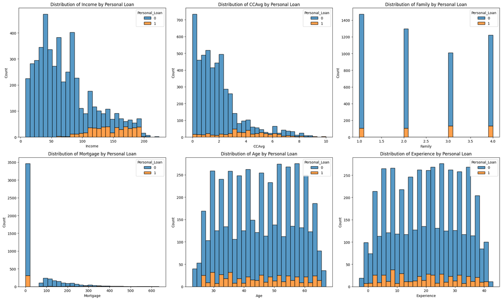

```python
# Feature distribution by target variable
features = ['Income', 'CCAvg', 'Family', 'Mortgage', 'Age', 'Experience']

plt.figure(figsize=(20, 12))
for i, feature in enumerate(features, 1):
    plt.subplot(2, 3, i)
    sns.histplot(data=data, x=feature, hue='Personal_Loan', multiple='stack', bins=30)
    plt.title(f'Distribution of {feature} by Personal Loan')
    plt.xlabel(feature)
    plt.ylabel('Count')
plt.tight_layout()
plt.show()
```

Investigate how family size impacts the likelihood of accepting a loan. Family size can be a significant factor in financial decision-making.

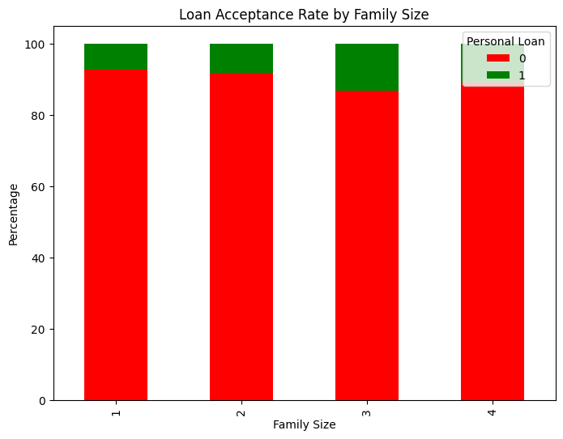

```python
# Loan acceptance rate by family size
family_loan = pd.crosstab(data['Family'], data['Personal_Loan'], normalize='index') * 100
family_loan.plot(kind='bar', stacked=True, color=['red', 'green'], figsize=(8, 6))
plt.title('Loan Acceptance Rate by Family Size')
plt.xlabel('Family Size')
plt.ylabel('Percentage')
plt.legend(title='Personal Loan', loc='upper right')
plt.show()
```

Income and Credit Card Spending (CCAvg) Interaction Investigate the relationship between income and average credit card spending (CCAvg) and how it relates to loan acceptance. High spending relative to income might be a strong predictor of loan acceptance.

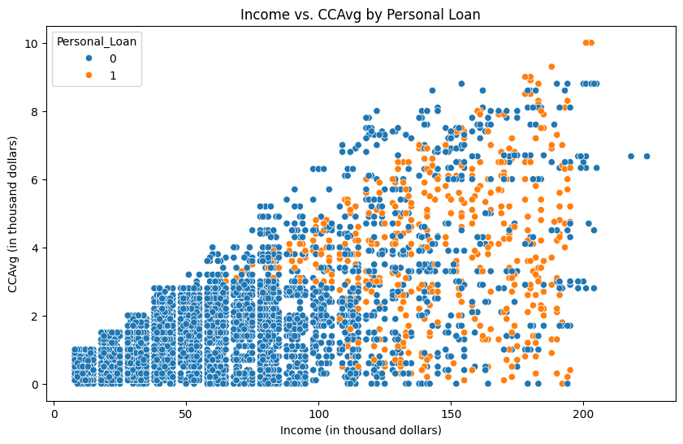

```python
# Relationship between Income and CCAvg by Personal Loan
plt.figure(figsize=(10, 6))
sns.scatterplot(x='Income', y='CCAvg', hue='Personal_Loan', data=data)
plt.title('Income vs. CCAvg by Personal Loan')
plt.xlabel('Income (in thousand dollars)')
plt.ylabel('CCAvg (in thousand dollars)')
plt.show()
```

Loan Acceptance Rate by Online Banking Usage Examine how the usage of online banking services correlates with the acceptance of a personal loan. Customers who use online services might be more likely to accept a loan due to ease of access.

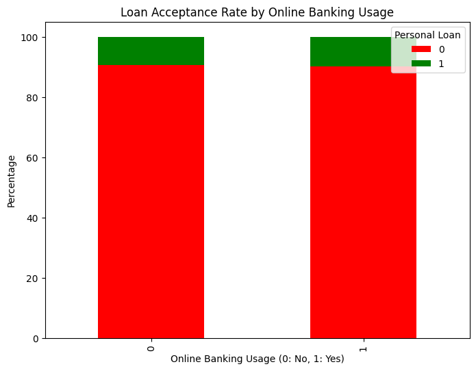

```python
# Loan acceptance rate by online banking usage
online_loan = pd.crosstab(data['Online'], data['Personal_Loan'], normalize='index') * 100
online_loan.plot(kind='bar', stacked=True, color=['red', 'green'], figsize=(8, 6))
plt.title('Loan Acceptance Rate by Online Banking Usage')
plt.xlabel('Online Banking Usage (0: No, 1: Yes)')
plt.ylabel('Percentage')
plt.legend(title='Personal Loan', loc='upper right')
plt.show()
```

Distribution of Experience Analyze the distribution of the Experience attribute, as it might influence a customer's financial stability and their decision to accept a loan.

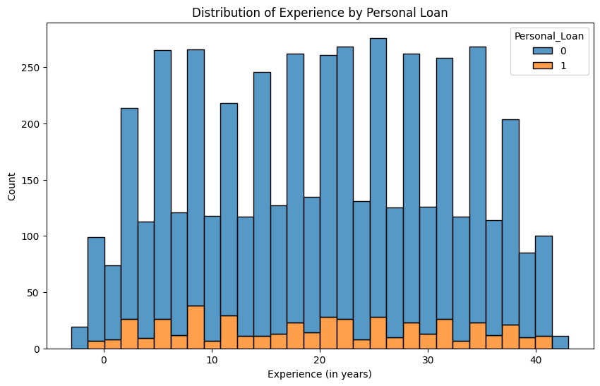

```python
# Distribution of Experience by Personal Loan
plt.figure(figsize=(10, 6))
sns.histplot(data=data, x='Experience', hue='Personal_Loan', multiple='stack', bins=30)
plt.title('Distribution of Experience by Personal Loan')
plt.xlabel('Experience (in years)')
plt.ylabel('Count')
plt.show()
```

Questions:

What is the distribution of mortgage attribute?

Are there any noticeable patterns or outliers in the distribution?

How many customers have credit cards?

What are the attributes that have a strong correlation with the target attribute (personal loan)?

How does a customer's interest in purchasing a loan vary with their age?

How does a customer's interest in purchasing a loan vary with their education?

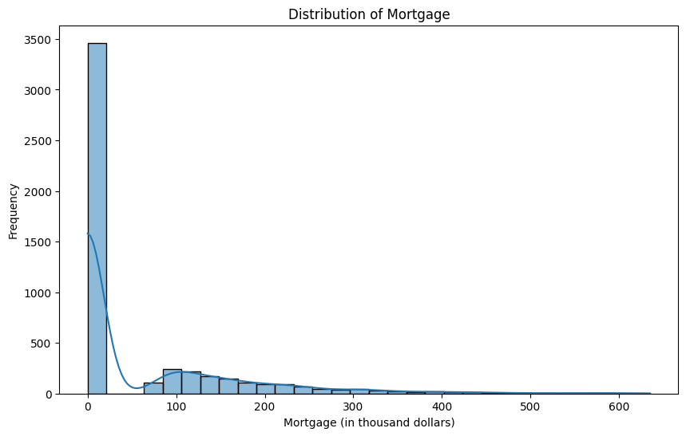

```python
#Mortgage attribute is distributed, identifying any patterns or outliers.
import matplotlib.pyplot as plt
import seaborn as sns

# Distribution of Mortgage
plt.figure(figsize=(10, 6))
sns.histplot(data['Mortgage'], kde=True, bins=30)
plt.title('Distribution of Mortgage')
plt.xlabel('Mortgage (in thousand dollars)')
plt.ylabel('Frequency')
plt.show()
```

The distribution appears to be right-skewed or positively skewed.

Count of Customers with Credit Cards We need to determine how many customers have credit cards.

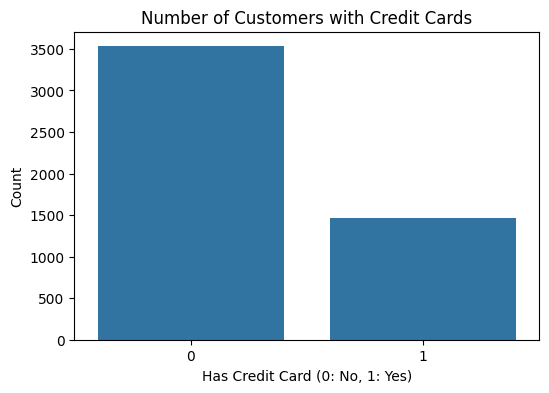

```
CreditCard
0    3530
1    1470
Name: count, dtype: int64
```

```python
# Count of customers with credit cards
credit_card_count = data['CreditCard'].value_counts()

# Visualizing the count
plt.figure(figsize=(6, 4))
sns.barplot(x=credit_card_count.index, y=credit_card_count.values)
plt.title('Number of Customers with Credit Cards')
plt.xlabel('Has Credit Card (0: No, 1: Yes)')
plt.ylabel('Count')
plt.show()

print(credit_card_count)
```

Correlation with Target Attribute (Personal Loan) Identify attributes that have a strong correlation with the Personal_Loan attribute.

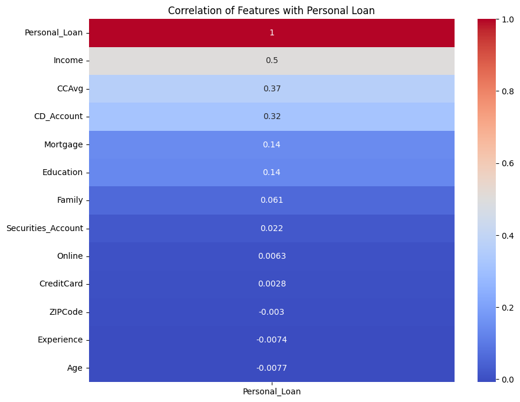

```python
# Correlation matrix
correlation_matrix = data.corr()

# Correlation with the target variable (Personal_Loan)
plt.figure(figsize=(10, 8))
sns.heatmap(correlation_matrix[['Personal_Loan']].sort_values(by='Personal_Loan', ascending=False), annot=True, cmap='coolwarm')
plt.title('Correlation of Features with Personal Loan')
plt.show()
```

Income: With a correlation coefficient of 0.5, there's a moderate positive correlation between income and the likelihood of taking a personal loan. This suggests that individuals with higher incomes are more likely to apply for personal loans.

CCAvg: Credit card average spending also shows a moderate positive correlation (0.37). This indicates that individuals with higher credit card spending tend to be more inclined to take personal loans.

CD_Account: The presence of a certificate of deposit (CD) account has a moderate positive correlation (0.32) with personal loans. This might suggest that individuals with CD accounts have a higher financial stability and are more likely to consider personal loans.

Customer's Interest in Loan Purchase vs. Education Investigate how interest in purchasing a loan varies with the education level of customers.

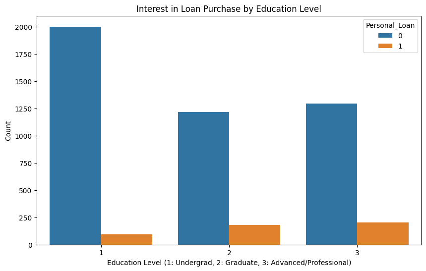

```python
# Relationship between education and interest in loan purchase
plt.figure(figsize=(10, 6))
sns.countplot(x='Education', hue='Personal_Loan', data=data)
plt.title("Interest in Loan Purchase by Education Level")
plt.xlabel('Education Level (1: Undergrad, 2: Graduate, 3: Advanced/Professional)')
plt.ylabel('Count')
plt.show()
```

Key Observations

Overall Interest: There seems to be a general increase in interest in loan purchase as education level rises.

Undergraduates (Level 1): The lowest interest is observed among undergraduates. Graduates (Level 2): A significant jump in interest is seen for graduates compared to undergraduates.

Advanced/Professional (Level 3): The highest level of interest in loan purchase is among customers with advanced or professional degrees.

Target Audience: The results suggest that graduates and individuals with advanced/professional degrees could be potential target audiences for loan marketing campaigns.

DATA PREPROCESSING

```python
#Feature Engineering
#grouping ages into age ranges like <30, 30-40, 40-50
#Income ,CCAvg might capture the effect of high income and high credit card spending together
#Income might help capture non-linear relationships.
#Applying a logarithmic transformation to skewed features to reduce the impact of outliers and normalize the distribution.
#creating a feature that represents the average spending on a credit card.

data['Age_Bin'] = pd.cut(data['Age'], bins=[0, 30, 40, 50, 60, 100], labels=['<30', '30-40', '40-50', '50-60', '>60'])
data['Income_CCAvg'] = data['Income'] * data['CCAvg']
from sklearn.preprocessing import PolynomialFeatures

poly = PolynomialFeatures(degree=2, include_bias=False)
poly_features = poly.fit_transform(data[['Income', 'CCAvg']])
data['Log_Income'] = np.log1p(data['Income'])
data['Avg_Spend'] = data[['CCAvg', 'Income']].mean(axis=1)
```

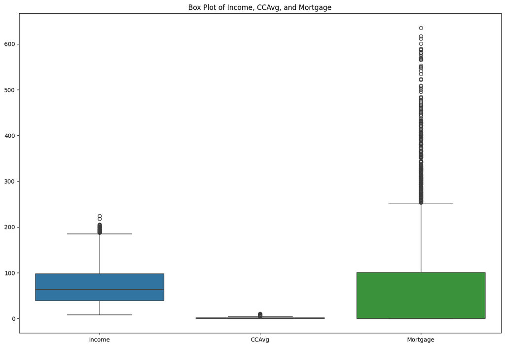

```python
#outlier detection using boxplot
# Detect outliers using a boxplot
plt.figure(figsize=(15, 10))
sns.boxplot(data=data[['Income', 'CCAvg', 'Mortgage']])
plt.title('Box Plot of Income, CCAvg, and Mortgage')
plt.show()

#Treatment : Capping Outliers
# Cap outliers in Income
Q1 = data['Income'].quantile(0.25)
Q3 = data['Income'].quantile(0.75)
IQR = Q3 - Q1
lower_bound = Q1 - 1.5 * IQR
upper_bound = Q3 + 1.5 * IQR

data['Income'] = np.where(data['Income'] < lower_bound, lower_bound, data['Income'])
data['Income'] = np.where(data['Income'] > upper_bound, upper_bound, data['Income'])
```

Income: There appears to be a significant number of outliers on the higher end of the Income distribution. These individuals have exceptionally high incomes compared to the majority of the dataset.

CCAvg: There are also some potential outliers on the higher end of the CCAvg distribution, indicating individuals with unusually high average credit card spending.

```python
# Option 1: Retain "Experience" with encoding (if needed)
from sklearn.preprocessing import OneHotEncoder
# Assuming "Experience" is categorical and needs one-hot encoding
encoder = OneHotEncoder(handle_unknown='ignore')
encoded_experience = pd.DataFrame(encoder.fit_transform(X[['Experience']]).toarray())
X = pd.concat([X, encoded_experience], axis=1)

# Option 2: Drop "Experience" entirely (if confirmed for removal)
# X = X.drop("Experience", axis=1)  # Uncomment if you want to drop

# Verify if 'Education' and 'ZIPCode' are present in X
print(X.columns)

# One-hot encode categorical features if 'Education' is present
if 'Education' in X.columns:
    X = pd.get_dummies(X, columns=["ZIPCode", "Education"], drop_first=True)
else:
    print("Warning: 'Education' column not found. Proceeding without one-hot encoding for it.")
    X = pd.get_dummies(X, columns=["ZIPCode"], drop_first=True)  # Encode only ZIPCode

# Splitting data into train and test sets
X_train, X_test, y_train, y_test = train_test_split(X, Y, test_size=0.30, random_state=1)

print("Shape of Training set : ", X_train.shape)
print("Shape of test set : ", X_test.shape)
print("Percentage of classes in training set:")
print(y_train.value_counts(normalize=True))
print("Percentage of classes in test set:")
print(y_test.value_counts(normalize=True))
```

```
Index([               'Age',         'Experience',             'Income',
                  'ZIPCode',             'Family',              'CCAvg',
                 'Mortgage', 'Securities_Account',         'CD_Account',
                   'Online',
       ...
                         37,                   38,                   39,
                         40,                   41,                   42,
                         43,                   44,                   45,
                         46],
      dtype='object', length=114)
Warning: 'Education' column not found. Proceeding without one-hot encoding for it.
Shape of Training set :  (3500, 579)
Shape of test set :  (1500, 579)
Percentage of classes in training set:
Personal_Loan
0    0.905429
1    0.094571
Name: proportion, dtype: float64
Percentage of classes in test set:
Personal_Loan
0    0.900667
1    0.099333
Name: proportion, dtype: float64
```

MODEL BUILDING

The model_performance_classification_sklearn function will be used to check the model performance of models.

The confusion_matrix_sklearnfunction will be used to plot confusion matrix.

```python
# defining a function to compute different metrics to check performance of a classification model built using sklearn
def model_performance_classification_sklearn(model, predictors, target):
    """
    Function to compute different metrics to check classification model performance

    model: classifier
    predictors: independent variables
    target: dependent variable
    """

    # predicting using the independent variables
    pred = model.predict(predictors)

    acc = accuracy_score(target, pred)  # to compute Accuracy
    recall = recall_score(target, pred)  # to compute Recall
    precision = precision_score(target, pred)  # to compute Precision
    f1 = f1_score(target, pred)  # to compute F1-score

    # creating a dataframe of metrics
    df_perf = pd.DataFrame(
        {"Accuracy": acc, "Recall": recall, "Precision": precision, "F1": f1,},
        index=[0],
    )

    return df_perf
```

[figure not shown]

```python
import pandas as pd
import numpy as np
import matplotlib.pyplot as plt
import seaborn as sns
from sklearn.metrics import confusion_matrix

def confusion_matrix_sklearn(model, predictors, target):
    """
    To plot the confusion_matrix with percentages

    model: classifier
    predictors: independent variables
    target: dependent variable
    """
    y_pred = model.predict(predictors)
    cm = confusion_matrix(target, y_pred)
    labels = np.asarray(
        [
            ["{0:0.0f}".format(item) + "\n{0:.2%}".format(item / cm.flatten().sum())]
            for item in cm.flatten()
        ]
    ).reshape(2, 2)

    plt.figure(figsize=(6, 4))
    sns.heatmap(cm, annot=labels, fmt="")
    plt.ylabel("True label")
    plt.xlabel("Predicted label")
    plt.show()

confusion_matrix_sklearn(model, X_test, y_test)
```

BUILD DECISION TREE MODEL

```
Index(['ID', 'Age', 'Experience', 'Income', 'ZIPCode', 'Family', 'CCAvg',
       'Education', 'Mortgage', 'Personal_Loan', 'Securities_Account',
       'CD_Account', 'Online', 'CreditCard'],
      dtype='object')
```

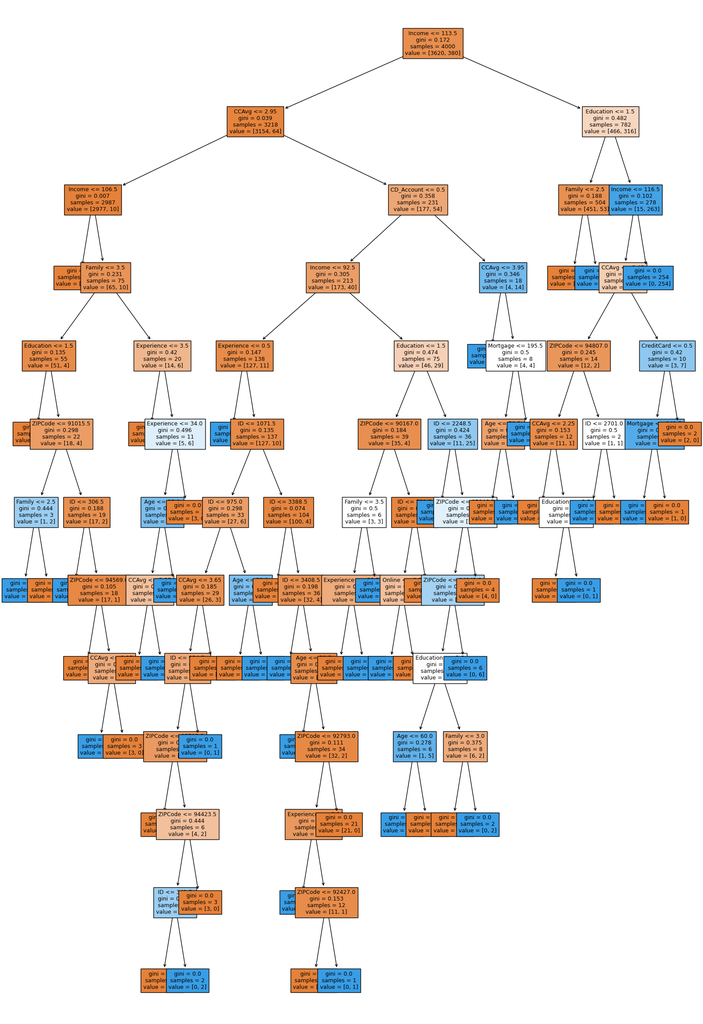

```
|--- Income <= 113.50
|   |--- CCAvg <= 2.95
|   |   |--- Income <= 106.50
|   |   |   |--- weights: [2912.00, 0.00] class: 0
|   |   |--- Income >  106.50
|   |   |   |--- Family <= 3.50
|   |   |   |   |--- Education <= 1.50
|   |   |   |   |   |--- weights: [33.00, 0.00] class: 0
|   |   |   |   |--- Education >  1.50
|   |   |   |   |   |--- ZIPCode <= 91015.50
|   |   |   |   |   |   |--- Family <= 2.50
|   |   |   |   |   |   |   |--- weights: [0.00, 2.00] class: 1
|   |   |   |   |   |   |--- Family >  2.50
|   |   |   |   |   |   |   |--- weights: [1.00, 0.00] class: 0
|   |   |   |   |   |--- ZIPCode >  91015.50
|   |   |   |   |   |   |--- ID <= 306.50
|   |   |   |   |   |   |   |--- weights: [0.00, 1.00] class: 1
|   |   |   |   |   |   |--- ID >  306.50
|   |   |   |   |   |   |   |--- ZIPCode <= 94569.00
|   |   |   |   |   |   |   |   |--- weights: [14.00, 0.00] class: 0
|   |   |   |   |   |   |   |--- ZIPCode >  94569.00
|   |   |   |   |   |   |   |   |--- CCAvg <= 1.15
|   |   |   |   |   |   |   |   |   |--- weights: [0.00, 1.00] class: 1
|   |   |   |   |   |   |   |   |--- CCAvg >  1.15
|   |   |   |   |   |   |   |   |   |--- weights: [3.00, 0.00] class: 0
|   |   |   |--- Family >  3.50
|   |   |   |   |--- Experience <= 3.50
|   |   |   |   |   |--- weights: [9.00, 0.00] class: 0
|   |   |   |   |--- Experience >  3.50
|   |   |   |   |   |--- Experience <= 34.00
|   |   |   |   |   |   |--- Age <= 35.00
|   |   |   |   |   |   |   |--- CCAvg <= 2.35
|   |   |   |   |   |   |   |   |--- weights: [2.00, 0.00] class: 0
|   |   |   |   |   |   |   |--- CCAvg >  2.35
|   |   |   |   |   |   |   |   |--- weights: [0.00, 1.00] class: 1
|   |   |   |   |   |   |--- Age >  35.00
|   |   |   |   |   |   |   |--- weights: [0.00, 5.00] class: 1
|   |   |   |   |   |--- Experience >  34.00
|   |   |   |   |   |   |--- weights: [3.00, 0.00] class: 0
|   |--- CCAvg >  2.95
```

[output cut: 123 more lines]

```

                         Imp
Education           0.393576
Income              0.312038
Family              0.148592
CCAvg               0.048041
ID                  0.022460
ZIPCode             0.020337
CD_Account          0.016799
Experience          0.014768
Age                 0.011856
Mortgage            0.006034
CreditCard          0.003562
Online              0.001939
Securities_Account  0.000000
```

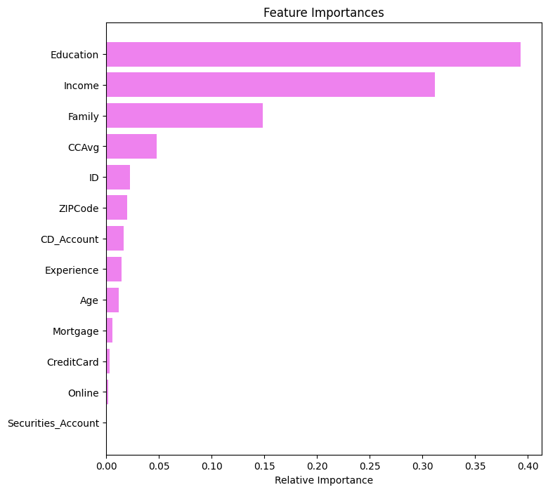

```python
from sklearn.tree import DecisionTreeClassifier, plot_tree,export_text
from sklearn.model_selection import train_test_split
import pandas as pd

# Load your data into variables X and y
data = pd.read_csv(file_path)

# Check for the correct column name and case
print(data.columns)  # Print the column names to verify

# Assuming the correct column name is 'Personal Loan' (adjust if needed)
X = data.drop('Personal_Loan', axis=1)
y = data['Personal_Loan']

# Now you can split the data
X_train, X_test, y_train, y_test = train_test_split(X, y, test_size=0.2, random_state=1)

model = DecisionTreeClassifier(criterion="gini", random_state=1)
model.fit(X_train, y_train)

decision_tree_perf_train = model_performance_classification_sklearn(
    model, X_train, y_train
)
decision_tree_perf_train

plt.figure(figsize=(20, 30))
out = plot_tree( # Use plot_tree directly
    model,
    feature_names=feature_names,
    filled=True,
    fontsize=9,
    node_ids=False,
    class_names=None,
)
# below code will add arrows to the decision tree split if they are missing
for o in out:
    arrow = o.arrow_patch
    if arrow is not None:
        arrow.set_edgecolor("black")
        arrow.set_linewidth(1)
plt.show()

# Text report showing the rules of a decision tree -

print(export_text(model, feature_names=feature_names, show_weights=True)) # Use export_text directly

# importance of features in the tree building ( The importance of a feature is computed as the
# (normalized) total reduction of the criterion brought by that feature. It is also known as the Gini importance )

print(
    pd.DataFrame(
        model.feature_importances_, columns=["Imp"], index=X_train.columns
    ).sort_values(by="Imp", ascending=False)
)

importances = model.feature_importances_
indices = np.argsort(importances)

plt.figure(figsize=(8, 8))
plt.title("Feature Importances")
plt.barh(range(len(indices)), importances[indices], color="violet", align="center")
plt.yticks(range(len(indices)), [feature_names[i] for i in indices])
plt.xlabel("Relative Importance")
plt.show()
```

Checking Performance on Test Data

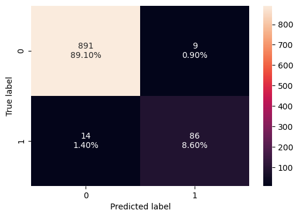

```
              precision    recall  f1-score   support

           0       0.98      0.99      0.99       900
           1       0.91      0.86      0.88       100

    accuracy                           0.98      1000
   macro avg       0.94      0.93      0.93      1000
weighted avg       0.98      0.98      0.98      1000
```

```python
import pandas as pd
import numpy as np
import matplotlib.pyplot as plt
import seaborn as sns
from sklearn.metrics import confusion_matrix, classification_report  # Import classification_report
from sklearn.tree import DecisionTreeClassifier
from sklearn.model_selection import train_test_split

def confusion_matrix_sklearn(model, predictors, target):
    """
    To plot the confusion_matrix with percentages

    model: classifier
    predictors: independent variables
    target: dependent variable
    """
    y_pred = model.predict(predictors)
    cm = confusion_matrix(target, y_pred)
    labels = np.asarray(
        [
            ["{0:0.0f}".format(item) + "\n{0:.2%}".format(item / cm.flatten().sum())]
            for item in cm.flatten()
        ]
    ).reshape(2, 2)

    plt.figure(figsize=(6, 4))
    sns.heatmap(cm, annot=labels, fmt="")
    plt.ylabel("True label")
    plt.xlabel("Predicted label")
    plt.show()

# Load your dataset here. Replace 'your_dataset.csv' with the actual file path
data = pd.read_csv('/content/drive/MyDrive/Personal Loan Campaign/Loan_Modelling.csv')

# Assuming 'data' is your pandas DataFrame containing the features and target variable
# Adjust 'target_variable_column' to the actual name of your target variable column
X = data.drop('Personal_Loan', axis=1)
y = data['Personal_Loan']

# Split the data into training and testing sets
X_train, X_test, y_train, y_test = train_test_split(X, y, test_size=0.2, random_state=1)

# Train the model here
model = DecisionTreeClassifier(criterion="gini", random_state=1) # Create the model instance
model.fit(X_train, y_train) # Fit the model

# Now you can create the confusion matrix
confusion_matrix_sklearn(model, X_test, y_test)

# Calculate and print classification report for test data
decision_tree_perf_test = classification_report(y_test, model.predict(X_test))  # Use classification_report
print(decision_tree_perf_test)
```

```python
# training performance comparison

# Train and evaluate the original Decision Tree model (without pre-pruning)
decision_tree_model = DecisionTreeClassifier(criterion="gini", random_state=1)
decision_tree_model.fit(X_train, y_train)
decision_tree_perf_train, _ = model_performance_classification_sklearn(decision_tree_model, X_train, y_train, 'train')
decision_tree_perf_test, _ = model_performance_classification_sklearn(decision_tree_model, X_test, y_test, 'test')

# Assuming the pre-pruned Decision Tree model results are in 'train_perf' and 'test_perf'
# from the previous code (ipython-input-21-...)
decision_tree_tune_perf_train = train_perf
decision_tree_tune_perf_test = test_perf

models_train_comp_df = pd.concat(
    [decision_tree_perf_train.T, decision_tree_tune_perf_train.T], axis=1,
)
models_train_comp_df.columns = ["Decision Tree sklearn", "Decision Tree (Pre-Pruning)"]
print("Training performance comparison:")
models_train_comp_df

# testing performance comparison

models_test_comp_df = pd.concat(
    [decision_tree_perf_test.T, decision_tree_tune_perf_test.T], axis=1, ## Complete the code to compare performance of test set
)
models_test_comp_df.columns = ["Decision Tree sklearn", "Decision Tree (Pre-Pruning)"]
print("Test performance comparison:")
models_test_comp_df
```

[output not shown]

[output not shown]

```
Training performance comparison:
Test performance comparison:
```

[output not shown]

Notes: The model performs well on overall performance

What recommedations would you suggest to the bank?

Deepen customer understanding: Utilize advanced analytics and clustering techniques to create detailed customer segments.

Leverage customer lifetime value: Identify and focus on high-value customers.

Improve model performance: Explore feature engineering, regular model retraining, ensemble methods, and explainable AI.

Optimize marketing campaigns: Utilize A/B testing, personalized marketing, and customer journey mapping.

Manage risk: Enhance credit scoring and implement advanced fraud detection systems.

Consider competitive landscape: Monitor competitors' strategies and offerings.

Ensure regulatory compliance: Adhere to relevant regulations and protect customer data.